# Week 2 Lab

You should verify all results using R, even if you compute them analytically first.

# Probability

1. A deck of cards contains 60 cards; 20 of the cards are land cards and the remaining 40 cards are non-land cards. If I draw seven cards from the deck at random, what is the probability that I get: Use R to compute all probabilities numerically. You may use `dhyper()` and `phyper()`.
   - three land cards?
   - more than three land cards?
   - between two and four land cards?

   What is the expected number of land cards when I draw seven cards at random?

   For this you need to think about what type of distribution it is. You can use Wikipedia. Compared to the lecture notes, it sounds like it is Binomial Distribution, but this is NOT the case. Binomial Distribution is every experiment is independent, this example is not as when you draw one card it changes the probability of the next one.

   This situation is not binomial, because the draws are not independent. The appropriate model is the hypergeometric distribution.

```r
dhyper(3, 20, 40, 7)
```

```
## [1] 0.2697637
```

```r
1- phyper(3, 20, 40, 7)
```

```
## [1] 0.1594732
```

Two ways of doing part iii

```r
diff(phyper(c(1,4), m = 20, n = 40, k = 7))
```

```
## [1] 0.7174256
```

```r
sum(dhyper(c(2:4), 20, 40, 7))
```

```
## [1] 0.7174256
```

2. The birthday problem is a famous problem in probability, in which we calculate how many people we would need to gather in a room before there is at least a $0.5$ probability that at least two of these people share a birthday. We assume that birthdays are uniformly distributed across the year, and that all birthdays are independent (i.e. no twins). Use `R` to calculate the probability for a room with $n$ people and plot the probabilities for various values of $n$. Use a reference line to show $p = 0.5$ on your plot. Choose sensible limits for the $x$ and $y$ axes.

Write a function that computes the probability for a given n. Use R to generate the plot.

```r
birthday_prob <- function(N){
  if(N <= 1){
    return(1)
  }
  return(birthday_prob(N - 1) * (365 - (N - 1)) / 365)
}

minusbirthday_prob <- function(N){
  return (1- birthday_prob(N))
}
```

```r
for(i in 2:60){
  print(paste(i, 1-birthday_prob(i)))
}
```

```
## [1] "2 0.00273972602739725"
## [1] "3 0.00820416588478146"
## [1] "4 0.0163559124665503"
## [1] "5 0.0271355736997937"
## [1] "6 0.0404624836491116"
## [1] "7 0.0562357030959756"
## [1] "8 0.0743352923516692"
## [1] "9 0.094623833889167"
## [1] "10 0.116948177711078"
## [1] "11 0.141141378321733"
## [1] "12 0.167024788838065"
## [1] "13 0.19441027523243"
## [1] "14 0.223102512004973"
## [1] "15 0.252901319763687"
## [1] "16 0.28360400525285"
```

[output cut: 44 more lines]

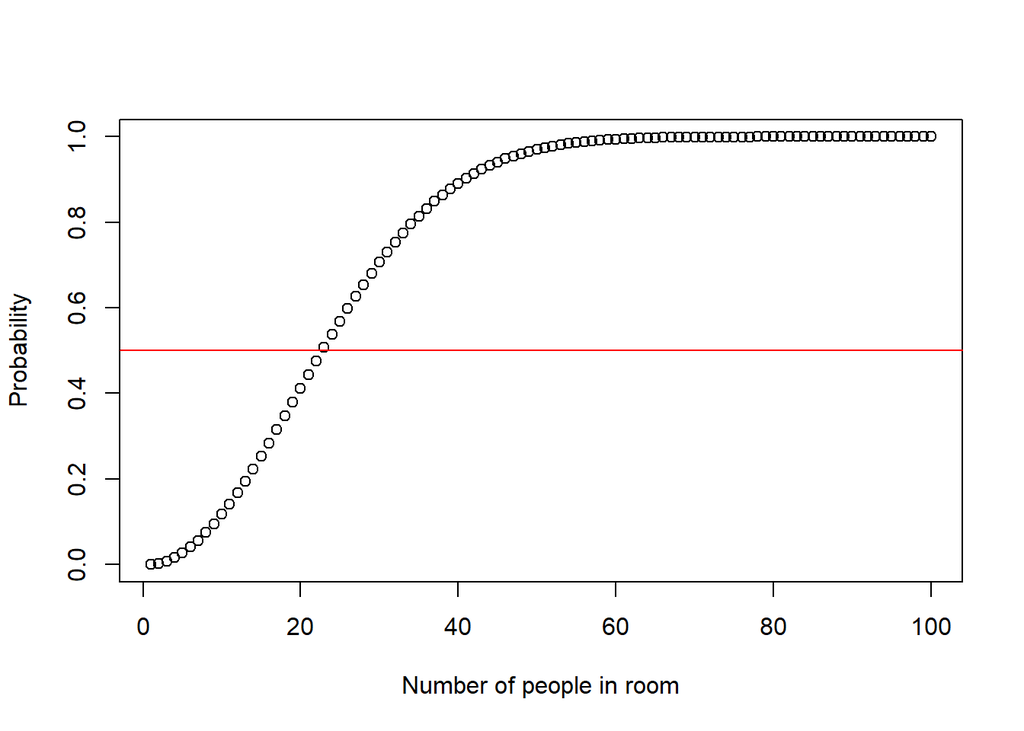

```r
n = 1:100
p = sapply(n, minusbirthday_prob)
plot(n, p, xlab = "Number of people in room", ylab = "Probability")
abline(h = 0.5, col = "red")
```

# Random Variables

Given the following random variables, use Wikipedia to find the expected value and variance. Make sure to describe what the expected value means for each distribution.

- $X$ is Binomial, with number of trials $n = 12$ and probability of success $p = 0.2$

$E[X]=np=2.4$, $Var(X)=np(1−p)=1.92$

- $A$ is Normal, with mean $\mu = 10$ and standard deviation $\sigma = 5$.

$E[A]=μ=10$, $Var(A)=σ^2=25$ - $B$ is Poisson with rate $\lambda = 4.5$.

$E[B]=λ=4.5$, $Var(B)=λ=4.5$

# Poisson approximation to binomial

Suppose that the Binomial distribution with parameters $n$ and $p$ is an appropriate model for a random variable $X$. If $n \ge 20$ and $p \le 0.05$, it can be shown that Poisson distribution can be used instead, as a good approximation, to work out probabilities about X.

The approximation is excellent if $n \ge 100$ and $np \le 10$.

Suppose that 1% of screws produced in a factory are defective. If 100 screws are selected at random, what is the (a) exact and (b) approximate probability that 5 of them will be defective.

1. Back to our binomial distribution function $P(X = x) = {n \choose x}p^x(1-p)^{n-x}$, go and calculate $P(X = 5)$, use the built in tools.

```r
dbinom(5, 100, 0.01)
```

```
## [1] 0.002897787
```

For binomial we have said the $\mu = E(X) = np$ which in this particular case is $(0.01)(100) = 1$\

For the Poisson distribution the $E(X) = \alpha t$. Putting them together we get an approximation for $\alpha t = 1$. We can now calculate $P(X=x) = e^{-\alpha t}\frac{(\alpha t)^{x}}{x!}$.

2. Find $P(X = 5)$ for Poisson

```r
dpois(5, 1)
```

```
## [1] 0.003065662
```

Are they close?

# Sampling Distribution - Central Limit Theorem

Let’s try this in practice

```r
a <- runif(10^6)
```

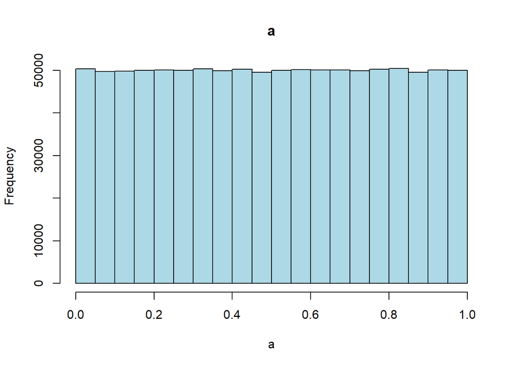

```r
hist(a, breaks = 20, main = "a", col = "lightblue")
```

Also let’s see the statistics

```r
cat("Population mean:", mean(a), "\n")
```

```
## Population mean: 0.500041
```

```r
cat("Standard deviation:", sd(a), "\n")
```

```
## Standard deviation: 0.2886656
```

From the population of 1,000,000 numbers, we are going to take 1000 random samples of size 100.

```r
b <- replicate(1000, sample(a, 100, replace = FALSE))
dim(b)
```

```
## [1]  100 1000
```

We now want the mean of each of these samples, so we want the mean of the columns, I would like there to be a function that does that! Call all these samplemeans sampleMean

```r
sampleMean = colMeans(b)
```

Now plot a histogram of sampleMean set.

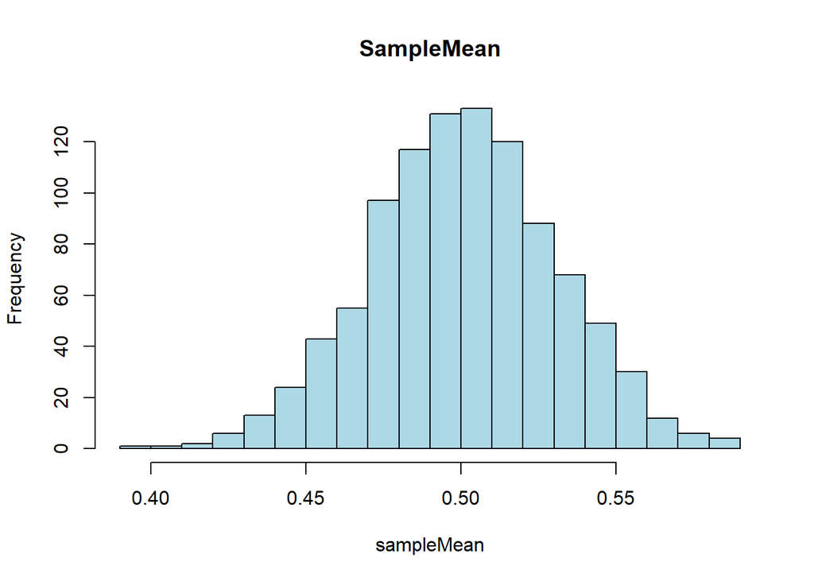

```r
hist(sampleMean, breaks = 20, main = "SampleMean", col = "lightblue")
```

Looks normal

What are the sample means and standard deviation of the sampleMeans

```r
cat("Mean of sampleMean:", mean(sampleMean), "\n")
```

```
## Mean of sampleMean: 0.5007674
```

```r
cat("Standard deviation of sampleMean:", sd(sampleMean), "\n")
```

```
## Standard deviation of sampleMean: 0.0302725
```

Sample mean quite close to population mean. SD of sample is quite close to SD of the population divided by $\sqrt{n}$

# Plotting expected values

```r
library(ggplot2)
```

The below is showing what I said in class, that the expected value will converge to the probability when we make the number of trials go towards infinity.

This example is for flipping a coin, the larger the number of trials the “closer” it is to the probability of 0.5 i.e. the expected value of 10,000 trials is 5,000

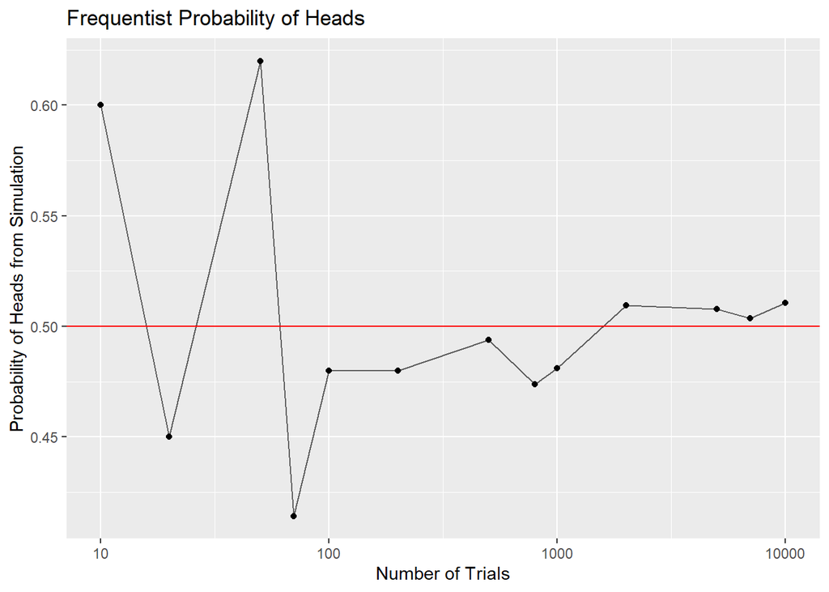

```r
throw_a_coin <- function(N) {
  sample(c("H", "T"), size = N, replace = TRUE)
}

# Define trials
trials <- c(10, 20, 50, 70, 100, 200, 500, 800, 1000, 2000, 5000, 7000, 10000)

# Compute probability of heads for each trial
prob_heads <- sapply(trials, function(j) sum(throw_a_coin(j) == "H") / j)

# Create a data frame for plotting
df <- data.frame(trials = trials, prob_heads = prob_heads)

# Plot the results
ggplot(df, aes(x = trials, y = prob_heads)) +
  geom_point() +
  geom_line(alpha = 0.6) +
  scale_x_log10() +  # Log scale for x-axis
  geom_hline(yintercept = 0.5, color = "red") +
  labs(
    x = "Number of Trials",
    y = "Probability of Heads from Simulation",
    title = "Frequentist Probability of Heads"
  )
```

Now something for you to do

Show that the expected value for a 6-sided dice is 3.5 by running trials and plotting it as above. Use at least 10,000 trials. Plot the running average against the number of trials.

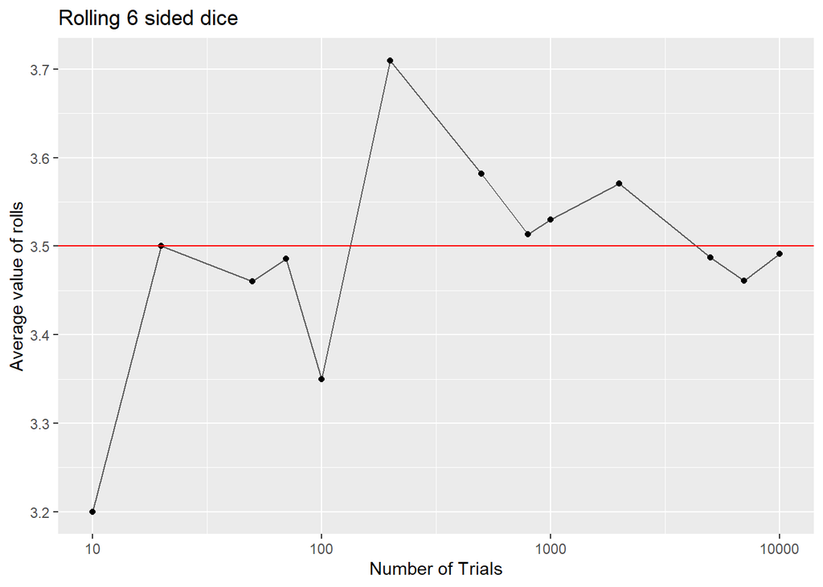

```r
roll_6 <- function(N) {
  sample(c(1,2,3,4,5,6), size = N, replace = TRUE)
}

# Define trials
trials <- c(10, 20, 50, 70, 100, 200, 500, 800, 1000, 2000, 5000, 7000, 10000)

# Compute probability of heads for each trial
prob_heads <- sapply(trials, function(j) sum(roll_6(j)) / j)

# Create a data frame for plotting
df <- data.frame(trials = trials, prob_heads = prob_heads)

# Plot the results
ggplot(df, aes(x = trials, y = prob_heads)) +
  geom_point() +
  geom_line(alpha = 0.6) +
  scale_x_log10() +  # Log scale for x-axis
  geom_hline(yintercept = 3.5, color = "red") +
  labs(
    x = "Number of Trials",
    y = "Average value of rolls",
    title = "Rolling 6 sided dice"
  )
```

What about a 12-sided dice?

# Normal Distribution Probabilities in R

When working with normally distributed random variables, we often need to calculate probabilities. In R, we use the `pnorm()` function to compute these probabilities.

## The `pnorm()` Function

The `pnorm()` function calculates the cumulative probability P(X ≤ x) for a normal distribution.

**Syntax:**

```r
pnorm(q, mean = 0, sd = 1, lower.tail = TRUE)
```

- `q`: the value(s) at which to evaluate the CDF
- `mean`: the mean of the distribution (default is 0)
- `sd`: the standard deviation (default is 1)
- `lower.tail`: if TRUE (default), returns P(X ≤ q); if FALSE, returns P(X > q)

## Example: Heights of Adult Women

Suppose the heights of adult women are normally distributed with: - Mean (μ) = 65 inches - Standard deviation (σ) = 3 inches

Let X represent the height of a randomly selected woman.

### Example 1: P(X < 68)

**Question:** What is the probability that a randomly selected woman is shorter than 68 inches?

```r
# P(X < 68) when X ~ N(65, 3)
prob1 <- pnorm(68, mean = 65, sd = 3)
print(paste("P(X < 68) =", round(prob1, 4)))
```

```
## [1] "P(X < 68) = 0.8413"
```

Can also use the z-transform

$P(X < 68) = P(\frac{X-\mu}{\sigma} < \frac{68-\mu}{\sigma}) = P(Z < \frac{68-65}{3}) = P(Z < 1)$

```r
pnorm(1)
```

```
## [1] 0.8413447
```

**Interpretation:** There is approximately an 84.13% chance that a randomly selected woman is shorter than 68 inches.

### Example 2: P(X > 68)

**Question:** What is the probability that a randomly selected woman is taller than 68 inches?

```r
# Method 1: Use lower.tail = FALSE
prob2a <- pnorm(68, mean = 65, sd = 3, lower.tail = FALSE)

# Method 2: Use the complement rule
prob2b <- 1 - pnorm(68, mean = 65, sd = 3)

print(paste("P(X > 68) =", round(prob2a, 4)))
```

```
## [1] "P(X > 68) = 0.1587"
```

```r
print(paste("Verification:", round(prob2b, 4)))
```

```
## [1] "Verification: 0.1587"
```

**Interpretation:** There is approximately a 15.87% chance that a randomly selected woman is taller than 68 inches.

### Example 3: P(62 < X < 68)

**Question:** What is the probability that a randomly selected woman has a height between 62 and 68 inches?

```r
# P(62 < X < 68) = P(X < 68) - P(X < 62)
prob_less_68 <- pnorm(68, mean = 65, sd = 3)
prob_less_62 <- pnorm(62, mean = 65, sd = 3)
prob3 <- prob_less_68 - prob_less_62

print(paste("P(X < 68) =", round(prob_less_68, 4)))
```

```
## [1] "P(X < 68) = 0.8413"
```

```r
print(paste("P(X < 62) =", round(prob_less_62, 4)))
```

```
## [1] "P(X < 62) = 0.1587"
```

```r
print(paste("P(62 < X < 68) =", round(prob3, 4)))
```

```
## [1] "P(62 < X < 68) = 0.6827"
```

**Interpretation:** There is approximately a 68.27% chance that a randomly selected woman has a height between 62 and 68 inches.

**Note:** This makes sense! For a normal distribution, about 68% of values fall within one standard deviation of the mean (65 ± 3 = [62, 68]).

## Visualizing the Probabilities

Let’s visualize these probabilities on the normal curve:

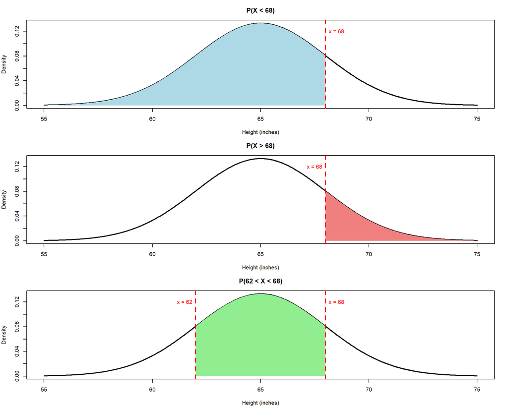

```r
# Set up the plotting area for 3 plots
par(mfrow = c(3, 1), mar = c(4, 4, 3, 2))

# Create a sequence of x values for plotting
x <- seq(55, 75, length.out = 1000)
y <- dnorm(x, mean = 65, sd = 3)

# Plot 1: P(X < 68)
plot(x, y, type = "l", lwd = 2,
     main = "P(X < 68)",
     xlab = "Height (inches)",
     ylab = "Density",
     xlim = c(55, 75))
# Shade the area
x_fill <- seq(55, 68, length.out = 1000)
y_fill <- dnorm(x_fill, mean = 65, sd = 3)
polygon(c(55, x_fill, 68), c(0, y_fill, 0), col = "lightblue", border = NA)
abline(v = 68, col = "red", lwd = 2, lty = 2)
text(68, max(y) * 0.9, "x = 68", pos = 4, col = "red")

# Plot 2: P(X > 68)
plot(x, y, type = "l", lwd = 2,
     main = "P(X > 68)",
     xlab = "Height (inches)",
     ylab = "Density",
     xlim = c(55, 75))
# Shade the area
x_fill <- seq(68, 75, length.out = 1000)
y_fill <- dnorm(x_fill, mean = 65, sd = 3)
polygon(c(68, x_fill, 75), c(0, y_fill, 0), col = "lightcoral", border = NA)
abline(v = 68, col = "red", lwd = 2, lty = 2)
text(68, max(y) * 0.9, "x = 68", pos = 2, col = "red")

# Plot 3: P(62 < X < 68)
plot(x, y, type = "l", lwd = 2,
     main = "P(62 < X < 68)",
     xlab = "Height (inches)",
     ylab = "Density",
     xlim = c(55, 75))
# Shade the area
x_fill <- seq(62, 68, length.out = 1000)
y_fill <- dnorm(x_fill, mean = 65, sd = 3)
polygon(c(62, x_fill, 68), c(0, y_fill, 0), col = "lightgreen", border = NA)
abline(v = c(62, 68), col = "red", lwd = 2, lty = 2)
text(62, max(y) * 0.9, "x = 62", pos = 2, col = "red")
text(68, max(y) * 0.9, "x = 68", pos = 4, col = "red")
```

```r
# Reset plotting parameters
par(mfrow = c(1, 1))
```